# Welcome to the Santa Barbara Data Science Meetup

## Thanks to our speaker, host, sponsors, and facilitators!

```python
Image(url='http://it-ebooks.info/images/ebooks/3/agile_data_science.jpg')
```

[figure not shown]

```python
from IPython.display import Image
Image(url='http://www.cloudpointasia.com/var/site/storage/images/media/images/site-images/logos/citrixonline_logo_web/96233-1-eng-GB/citrixonline_logo_web.gif')
```

```python
Image(url='http://www.theactivityexchange.com/images/logo_small.png')
```

## The Santa Barbara R Users Group:

http://www.meetup.com/Santa-Barbara-R-Users-Group/

# What is Data Science?

- The sexiest job of the century: [Harvard Business Review (2012)](http://hbr.org/2012/10/data-scientist-the-sexiest-job-of-the-21st-century/)

> [...] the “data scientist.” It’s a high-ranking professional with the training and curiosity to make discoveries in the world of big data. The title has been around for only a few years. (It was coined in 2008 by one of us, D.J. Patil, and Jeff Hammerbacher, then the respective leads of data and analytics efforts at LinkedIn and Facebook.)
- Something that should be done by statisticians, [but it isn't](http://simplystatistics.org/2013/06/14/the-vast-majority-of-statistical-analysis-is-not-performed-by-statisticians/)

> As the price of data dropped so dramatically over the last two decades, the division of labor between analysts and everyone else became less and less clear. Data became so cheap that it couldn’t be confined to just a few highly trained people.

# OK, it's trendy and misused... but what is it, really?

```python
# The Data Science Venn Diagram (1.0) — Drew Conway
Image(url='http://static.squarespace.com/static/5150aec6e4b0e340ec52710a/t/51525c33e4b0b3e0d10f77ab/1364352052403/Data_Science_VD.png?format=750w')
```

[figure not shown]

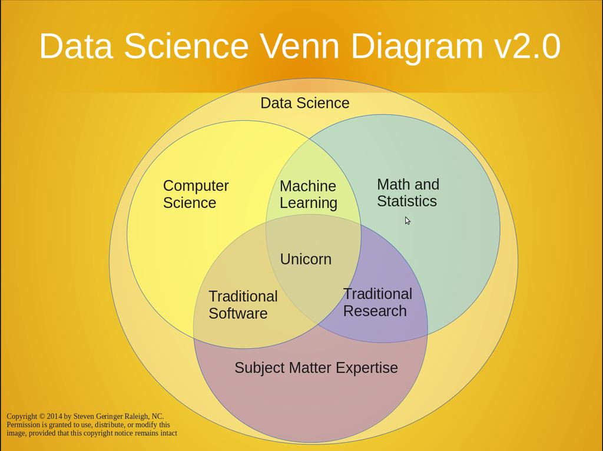

```python
# Venn Diagram 2.0, Steven Geringer
Image('http://2.bp.blogspot.com/-Qi-0utjhySM/UsteLrV6NyI/AAAAAAAACNQ/AdkizQfS8l8/s1600/moz-screenshot-3-729576.png')
```

# Data Science = ?

$$ \bigcup skills $$

or

$$ \bigcap skills $$

## Let's look at the data!

# A Meetup group dissection

```python
import urllib2
import json

# Download all info from all the Data Science Meetup members.
members = json.loads(urllib2.urlopen(
    "http://api.meetup.com/2/members?order=name" +
    "&group_urlname=Santa-Barbara-Data-Science&offset=0&format=json&page=150" +
    "&sig_id=66734052&sig=f7fc02b7069092e6775332b25f01b69e21346b92"
    ).read())

bios = [{'name' : x['name'], 'bio': x['bio']} for x in members['results'] ]
bios[-2:]
```

```
[{'bio': u'; . )', 'name': u'violet'},
 {'bio': u'Professor of Computer Science at Westmont; Consultant on data mining and prediction problems',
  'name': u'Wayne Iba'}]
```

```python
import nltk
from collections import Counter

# Find all the named entities.
entity_counter = Counter()
for x in bios:
    text = nltk.wordpunct_tokenize(x['bio'])
    for name,tag in nltk.pos_tag(text):
        if tag == 'NNP':
            entity_counter.update([name.capitalize()])
entity_counter.most_common(5)
```

```
[(u'Ucsb', 21), (u'Appfolio', 13), (u'Hi', 10), (u'Data', 10), (u'Phd', 10)]
```

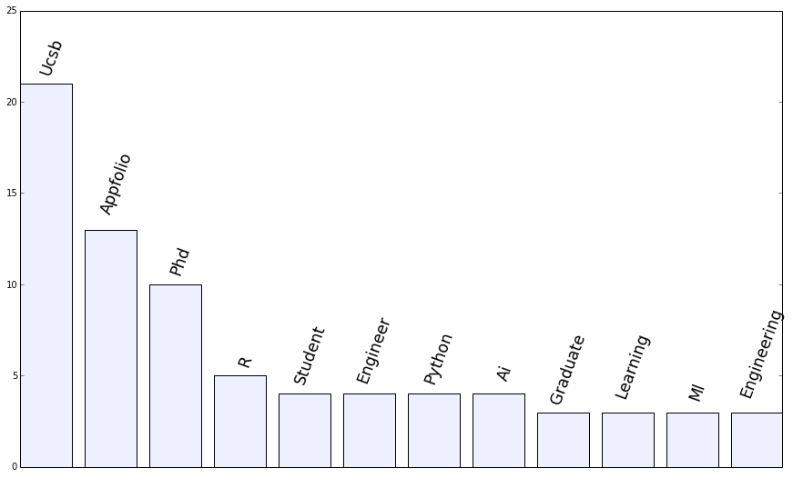

```python
import matplotlib.pyplot as plt
import numpy as np
fig = plt.figure(figsize=(15,9)); ax = fig.add_subplot(111); ax.set_xticks([]);
names,counts=zip(*[(name, count) for name, count in entity_counter.most_common(20)
     if name not in ['Data', 'Hi','Santa', 'Barbara','D','Ph', 'My', 'Science']])
x_pos = np.arange(len(counts))
plt.bar(x_pos - .4, counts, color = '#eeefff');
for x, y, label in zip(x_pos, counts, names): plt.annotate(label,
    (x+0.1, y + len(label)/2.2), ha='center', rotation=70, size='xx-large')
```

```python
from itertools import product
#Create a topic co-occurrence graph. Nodes are topics, edges between a,b means that a member listed both a,b as topics
nodes = Counter()
edges = Counter()

for x in members['results']:
    for y in x['topics']:
        nodes.update([y['name']])
    edges.update([(a['name'],b['name'])
          for a,b in product(x['topics'],x['topics']) if a['name'] > b['name']])

nodes.most_common(10)
```

```
[(u'Machine Learning', 50),
 (u'Data Mining', 49),
 (u'Programming', 45),
 (u'Big Data', 44),
 (u'Internet & Technology', 35),
 (u'New Technology', 33),
 (u'Web Development', 33),
 (u'Software Developers', 30),
 (u'Computer Science', 30),
 (u'Entrepreneurship', 29)]
```

```python
import networkx as nx

g = nx.Graph()
node_names = set()

for name, count in nodes.most_common(20):
    g.add_node(name, count=count)
    node_names.add(name)

for edge, count in edges.iteritems():
    if edge[0] in node_names and edge[1] in node_names:
        g.add_edge(edge[0], edge[1], weight = count)

labels = dict([(name, name.replace(' ','\n')) for name,_ in nodes.most_common(20)])
```

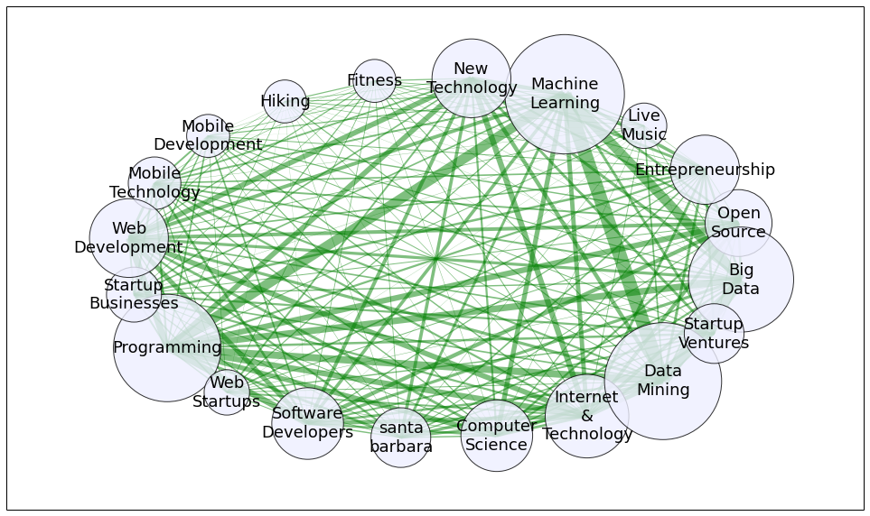

```python
fig = plt.figure(figsize=(17, 10)); ax = fig.add_subplot(111)
pos = nx.spring_layout(g,k=4.9, scale = 1000.0)
nx.draw_networkx_nodes(g, pos, node_size = [7*(d['count']**2)
        for _, d in g.nodes_iter(data=True)], alpha = 0.8, node_color = '#eeefff')
nx.draw_networkx_labels(g, pos, labels, font_size=18);
nx.draw_networkx_edges(g, pos, width=  [(d['weight']/10.0)**2
        for _, _, d in g.edges_iter(data=True)], alpha = 0.5, edge_color = 'g')
ax.set_xticks([]);ax.set_yticks([]);
```

# That's us!

- Mixed group: industry and academia
- Interest in
  - Machine Learning
  - Big Data
  - Programming
  - Computer Science

The data seems to be more consistent with the

$$\bigcup skills$$

hypotesis.

## Except, there seems to be a lack of *domain expertise*

# Resources:

- [DataTau](http://www.datatau.com/): The [HN](https://news.ycombinator.com/) for data science
- [Applied Predictive Modeling](http://appliedpredictivemodeling.com/) by Max Kuhn and Kjell Johnson: Practical predictive modeling in R
- [DARPA Open Catalog](http://www.darpa.mil/OpenCatalog/index.html): "a curated list of DARPA-sponsored software and peer-reviewed publications [...] in a variety of areas including data science, cyber, anomaly detection, etc.,"
- [Berkeley AMPlab](https://amplab.cs.berkeley.edu/) [Big Data Benchmark](https://amplab.cs.berkeley.edu/benchmark/): To quickly get up and running with Big Data deployment
- [R bloggers](http://www.r-bloggers.com/): Data Science for R
- [KDNuggets](http://www.kdnuggets.com/): Data mining
- [Kaggle](http://www.kaggle.com/): Data mining competitions and community
- Other Data Meetups in CA: [SF Data Mining](http://www.meetup.com/Data-Mining/) (5.2k members), [LA Machine Learning](http://www.meetup.com/LA-Machine-Learning/) Data Science Track. [First meeting](http://www.meetup.com/LA-Machine-Learning/events/161322792/) on Feb 18th (tomorrow!)